# Workflow for Snowy Owl Population Trends

Brian W. Rolek

2024-03-08

Supplemental materials for: McCabe, R.A., Aarvak, T., Aebischer, A., Bates, K., Bêty, J., Bollache, L., Brinker, D., Driscoll, C., Elliott, K.H., Fitzgerald, G., Fuller, M., Gauthier, G., Gilg, O., Gousy-Leblanc, M., Holt, D., Jacobsen, K.O., Johnson, D., Kulikova, O., Lang, J., Lecomte, N., McClure, C., McDonald, T., Menyushina, I., Miller, E., Morozov, V.V., Øien, I.J., Robillard, A., Rolek, B., Sittler, B., Smith, N., Sokolov, A., Sokolova, N., Solheim, R., Soloviev, M., Stoffel, M., Weidensaul, S., Wiebe, K.L., Zazelenchuck, D., and Therrien, J.F.. 2024. Status assessment and conservation priorities for a circumpolar raptor: the snowy owl. Bird Conservation International.

Metadata, data, and scripts used in analyses can be found at https://github.com/The-Peregrine-Fund/Snowy-Owl-Population-Trends.

The full workflow below is visible as a html website at: https://the-peregrine-fund.github.io/Snowy-Owl-Population-Trends/.

# 1 Simulations: Can regression models detect population declines when counts have cycles?

Here, we simulate data of an irruptive species using a zero-inflated poisson to induce cycles. Then we analyze it using a negative binomial.

```r
library(nimble)
library(MCMCvis)
library (MASS)
library (pscl)
```

## 1.1 A function to simulate cyclical time series

```r
sim.ts <- function( period = 4,
                    ntime = 30,
                    mn.psi = -1.38, # about 1/5
                    mn.abund = 10,
                    beta0 = -0.7,
                    beta1 = 2,
                    beta2 = 2,
                    plot.ts = TRUE){
          yr2 <- 1:ntime
          yr <- (yr2-(ntime/2+0.5))/(ntime/2-0.5)
          period2 <- (yr[2]-yr[1])*period
          # decreasing abundance over time
          lambda <- exp( log(mn.abund) + beta0*yr )
          # irruptive cycles as a zero-inflation parameter
          psi <- plogis(mn.psi +
                          beta1 * sin(2*pi*(yr/period2)) +
                          beta2 * cos(2*pi*(yr/period2)))
          # simulate abundance
          z <- rbinom(length(psi), size=1, prob=psi)
          mu <- lambda*z
          abund <- rpois(length(mu), mu)
          if(plot.ts==TRUE){
            plot(abund, type="l",
                 xlab="Year", ylab="Abundance")
          }
          return(list(datl = list(y = abund),
                      constl = list(ntime = ntime,
                                    yr = yr,
                                    period=period2*5),
                       truth = list(mn.psi = mn.psi,
                            mn.abund = mn.abund,
                            beta0 = beta0,
                            beta1 = beta1,
                            beta2 = beta2)
                      ))
}
```

## 1.2 Simulate data and implement negative binomial regression

```r
#*******************
#* Frequentist analysis
#* using a
#* negative binomial distribution
#*******************
set.seed(123456)
# Population trends vary
df <- data.frame(est=NA, truth=NA, bias=NA, cov=NA, lci=NA, uci=NA)
war <- rep(FALSE, 5000)
ind <- 1
beta.scenarios <- c(-0.7, -0.35, 0, 0.35, 0.7)
for (j in 1:length(beta.scenarios)){
  for (i in 1:1000){
    dat <- sim.ts(beta0=beta.scenarios[j], plot.ts=FALSE)
    dfm <- data.frame(y=dat$datl$y, yr=dat$constl$yr)
    fit <- tryCatch(glm(y ~ 1 + yr, family = negative.binomial(2),
                        data = dfm),
                    warning= function(w) {  return(TRUE) } )
    if (is.logical(fit)){ war[ind] <- fit
    ind <- ind+1
    next} else{
      out <- summary(fit)
      uci <- out$coefficients[2,1] + 1.96*out$coefficients[2,2]
      lci <- out$coefficients[2,1] - 1.96*out$coefficients[2,2]
      estimate <- out$coefficients[2,1]
      truth <- dat$truth$beta0
      relbias <- ifelse(truth==0,
                        ((estimate+1)-(truth+1))/(truth+1),
                        (estimate-truth)/truth)
      coverage <- ifelse(lci>=truth | uci<=truth, 0, 1)
      df[ind, 1:6] <- c(estimate, truth, relbias, coverage, lci, uci)
      ind <- ind + 1
    }
  }}
df1 <- df[war!=TRUE,]

#* Abundance varies
set.seed(123456)
df <- data.frame(est=NA, truth=NA, bias=NA, cov=NA, lci=NA, uci=NA, abund=NA)
war <- rep(FALSE, 4000)
ind <- 1
abund.scenarios <- c(0.5, 1, 2, 3)
for (j in 1:length(abund.scenarios)){
  for (i in 1:1000){
    dat <- sim.ts(mn.abund=abund.scenarios[j], plot.ts=FALSE)
    dfm <- data.frame(y=dat$datl$y, yr=dat$constl$yr)
    fit <- tryCatch(glm(y ~ 1 + yr, family = negative.binomial(2),
                        data = dfm),
                    warning= function(w) {  return(TRUE) } )
    if (is.logical(fit)){ war[ind] <- fit
    ind <- ind+1
    next} else{
      out <- summary(fit)
      uci <- out$coefficients[2,1] + 1.96*out$coefficients[2,2]
      lci <- out$coefficients[2,1] - 1.96*out$coefficients[2,2]
      estimate <- out$coefficients[2,1]
      truth <- dat$truth$beta0
      relbias <- ifelse(truth==0,
                        ((estimate+1)-(truth+1))/(truth+1),
                        (estimate-truth)/truth)
      coverage <- ifelse(lci>=truth |
                           uci<=truth, 0, 1)
      df[ind, 1:7] <- c(estimate, truth, relbias, coverage, lci, uci, abund.scenarios[j])
      ind <- ind + 1
    }
  }}
# need to remove mods that didn't converge.
df2 <- df[war!=TRUE,]

#* Lengths of time vary
set.seed(123456)
df <- data.frame(est=NA, truth=NA, bias=NA, cov=NA, lci=NA, uci=NA, time=NA)
war <- rep(FALSE, 3000)
ind <- 1
time.scenarios <- c(5, 10, 15)
for (j in 1:length(time.scenarios)){
  for (i in 1:1000){
    dat <- sim.ts(ntime=time.scenarios[j], plot.ts=FALSE)
    dfm <- data.frame(y=dat$datl$y, yr=dat$constl$yr)
    fit <- tryCatch(glm(y ~ 1 + yr,
                        family = negative.binomial(2),
                        data = dfm),
                    warning= function(w) {  return(TRUE) } )
    if (is.logical(fit)){ war[ind] <- fit
    ind <- ind+1
    next} else{
      out <- summary(fit)
      uci <- out$coefficients[2,1] + 1.96*out$coefficients[2,2]
      lci <- out$coefficients[2,1] - 1.96*out$coefficients[2,2]
      estimate <- out$coefficients[2,1]
      truth <- dat$truth$beta0
      relbias <- ifelse(truth==0,
                        ((estimate+1)-(truth+1))/(truth+1),
                        (estimate-truth)/truth)
      coverage <- ifelse(lci>=truth |
                           uci<=truth, 0, 1)
      df[ind, 1:7] <- c(estimate, truth, relbias, coverage, lci, uci, time.scenarios[j])
      ind <- ind + 1
    }
  }}
# need to remove mods that didn't converge
df3 <- df[war!=TRUE,]
```

## 1.3 Plot simulation results

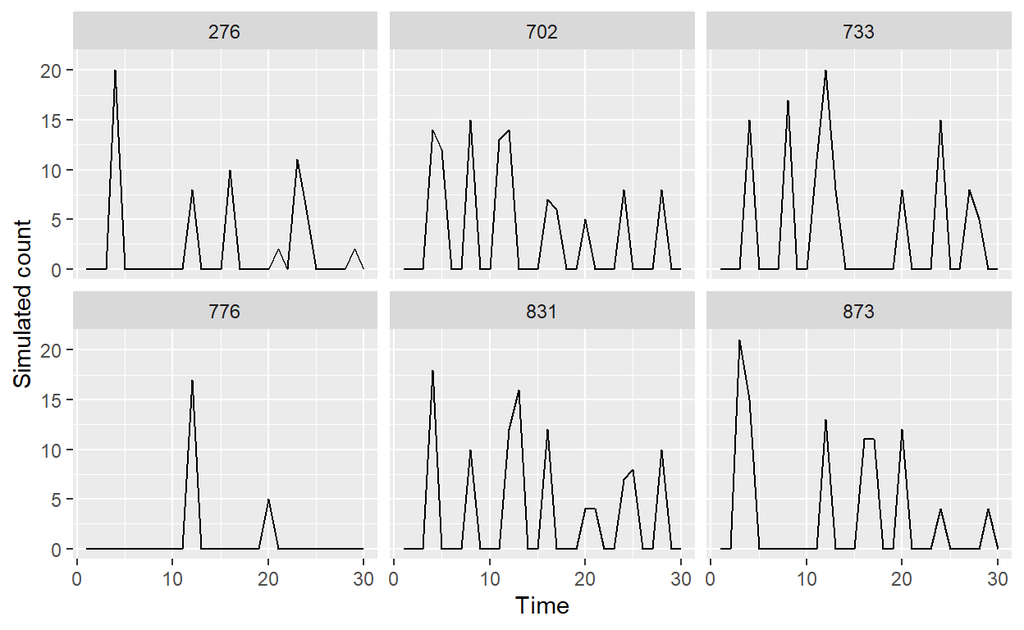

Fig. S1. Six randomly selected simulations among a total of 1000 for one scenario (mean abundance = 10, duration = 30-years and temporal trend of abundance = -0.7) designed to resemble counts from an irruptive species.

```r
# plot a sample of time series
dat <- list()
for (i in 1:1000){
  dat[[i]] <- sim.ts(beta0=beta.scenarios[1], plot.ts=FALSE)[[1]]$y
}
samps <- sample(1:1000, size=6, replace = FALSE)
df <- do.call(rbind, dat[samps])
library (reshape2)
library(ggplot2)
rownames(df) <- samps
ldf <- melt(df)

ggplot(ldf)+
  geom_line(aes(x=Var2, y=value)) +
  facet_wrap('Var1') +
  ylab("Simulated count") +
  xlab("Time")
```

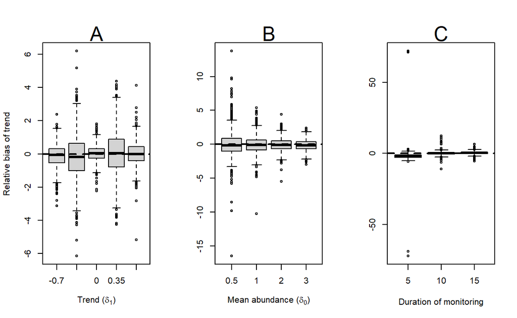

Fig. S2. Relative bias of population trends estimated by generalized linear models with a negative binomial distribution according to: (A) magnitude of 30-year temporal trend of abundance, (B) mean abundance, and (C) duration of monitoring. The dashed line depicts unbiased estimates. Solid horizontal lines within each box depict medians (50th percentile); boxes depict the 25th and 75th percentiles; whiskers depict the largest and smallest values within 1.5 times the interquartile range; outlier data are depicted as open circles; and a dashed line at no bias (zero) is provided for reference. For each scenario, we simulated 1000 time series data sets.

```r
# Plots
par(mfrow=c(1,3))
boxplot(df1$bias~df1$truth,
        xlab=expression(paste("Trend (", delta[1],")")),
        ylab="Relative bias of trend")
abline(h=0, lty=2, lwd=2)
mtext("A", cex=1.5, side=3, outer=F)

boxplot(df2$bias~df2$abund,
        xlab=expression(paste("Mean abundance (", delta[0],")")),
        ylab="")
abline(h=0, lty=2, lwd=2)
mtext("B", cex=1.5, side=3, outer=F)

boxplot(df3$bias~df3$time,
        xlab="Duration of monitoring",
        ylab="")
abline(h=0, lty=2, lwd=2)
mtext("C", cex=1.5, side=3, outer=F)
```

## 1.4 Create a table of simulation results

```r
# tables
tab1 <- data.frame(
                  # different population trends
                  varied.by= "population trends",
                  mn.abund=10,
                  trend= c(-0.7, -0.35, 0, 0.35, 0.7),
                  duration=30,
                  mean.rel.bias=tapply(df1$bias, df1$truth, mean),
                  sd.rel.bias=tapply(df1$bias, df1$truth, sd),
                  coverage=tapply(df1$cov, df1$truth, mean)
)
tab2 <- data.frame(
                  #* test different levels of abundance
                  varied.by= "abundance",
                  mn.abund=c(0.5, 1, 2, 3),
                  trend=-0.7,
                  duration=30,
                  mean.rel.bias=tapply(df2$bias, df2$abund, mean),
                  sd.rel.bias=tapply(df2$bias, df2$abund, sd),
                  coverage=tapply(df2$cov, df2$abund, mean)
)
tab3 <- data.frame(
                  #* test different lengths of time
                  varied.by= "duration",
                  mn.abund=10,
                  trend=-0.7,
                  duration=c(5, 10, 15),
                  mean.rel.bias=tapply(df3$bias, df3$time, mean),
                  sd.rel.bias=tapply(df3$bias, df3$time, sd),
                  coverage=tapply(df3$cov, df3$time, mean)
)
tab <- rbind(tab1, tab2, tab3)
rownames(tab) <- NULL
knitr::kable(tab, digits=c(0, 2, 2, 2, 2),
             col.names = c("Scenario", "Abundance", "Trend", "Duration",
                           "Mean relative bias", "SD relative bias", "Coverage"),
             row.names=FALSE,
             caption="Table S1. Simulation scenarios and results.")
```

Table S1. Simulation scenarios and results.

| Scenario | Abundance | Trend | Duration | Mean relative bias | SD relative bias | Coverage |
| --- | --- | --- | --- | --- | --- | --- |
| population trends | 10.0 | -0.70 | 30 | -0.11 | 1 | 0.98 |
| population trends | 10.0 | -0.35 | 30 | -0.18 | 1 | 0.98 |
| population trends | 10.0 | 0.00 | 30 | 0.03 | 0 | 0.97 |
| population trends | 10.0 | 0.35 | 30 | 0.07 | 1 | 0.98 |
| population trends | 10.0 | 0.70 | 30 | 0.02 | 1 | 0.98 |
| abundance | 0.5 | -0.70 | 30 | 0.02 | 2 | 0.93 |
| abundance | 1.0 | -0.70 | 30 | -0.10 | 1 | 0.96 |
| abundance | 2.0 | -0.70 | 30 | -0.09 | 1 | 0.97 |
| abundance | 3.0 | -0.70 | 30 | -0.15 | 1 | 0.98 |
| duration | 10.0 | -0.70 | 5 | -1.92 | 5 | 0.95 |
| duration | 10.0 | -0.70 | 10 | -0.02 | 2 | 0.96 |
| duration | 10.0 | -0.70 | 15 | 0.25 | 1 | 0.96 |

# 2 Snowy Owl Analyses

## 2.1 Posterior predictive checks to assess goodness-of-fit

We tested the goodness-of-fit using posterior predictive checks for three distributions: poisson, negative binomial, and zero-inflated Poisson. First we load the required packages and snowy owl data.

```r
library ('nimble')
library ('nimbleHMC')
library ('MCMCvis')
library ('coda')
library('parallel')
load("data/data.Rdata")
set.seed(5757575)
```

Next, we implemented goodness-of-fit checks for a Poisson, negative binomial, and zero-inflated Poisson distribution. The model using a negative binomial had much greater fit; therefore, we retained this for inference in the manuscript.

### 2.1.1 Poisson distribution

```r
#***********************
#* Poisson model
#***********************
run <- function(seed, datl, constl){
  library('nimble')
  library('coda')
  library ('nimbleHMC')
  code <- nimbleCode(
    {
      # priors
      for (j in 1:nsite){
        mu[j] ~ dnorm(0, sd=5) # constrain to reasonable values <exp(5) or <148
        beta[j] ~ dnorm(0, sd=5)
      }
      sigma.time ~ dexp(2)
      # likelihood
      for (t in 1:ntime){
        for (j in 1:nsite){
          y[t,j] ~ dpois(lambda[t,j])
          # abundance
          log(lambda[t,j]) <- mu[j] +
            beta[j]*time[t] +
            eps.time[t]
        } # j
        eps.time[t] ~ dnorm(0, sd=sigma.time)
      } # t

      ###################
      # Assess GOF of the models for counts
      # Step 1: Compute statistic for observed data
      # Step 2: Use discrepancy measure: mean absolute error
      # Step 3: Use test statistic: number of turns
      ###################
      # GOF for model
      for (t in 1:ntime){
        for (j in 1:nsite){
          c.obs[t,j] <- y[t,j] # observed counts
          c.exp[t,j] <- lambda[t,j] # expected counts adult breeder
          c.rep[t,j] ~ dpois(lambda[t,j]) # expected counts
          # Compute fit statistics, Mean absolute error
          dssm.obs[t,j] <- abs( ( (c.obs[t,j]) - (c.exp[t,j]) ) / (c.obs[t,j]+0.001) )
          dssm.rep[t,j] <- abs( ( (c.rep[t,j]) - (c.exp[t,j]) ) / (c.rep[t,j]+0.001) )
        } } # j # t
      dmape.obs <- sum(dssm.obs[1:ntime,1:nsite])
      dmape.rep <- sum(dssm.rep[1:ntime,1:nsite])
      # variance-mean ratio
      tvm.rep <- sd(c.rep[1:ntime,1:nsite])^2/mean(c.rep[1:ntime,1:nsite])
      tvm.obs <- sd(y[1:ntime,1:nsite])^2/mean(y[1:ntime,1:nsite])
    }
  ) # end model

  params <- c(    "sigma.time",
                  "mu", "beta",
                  "dssm.obs", "dssm.rep",
                  "dmape.obs", "dmape.rep",
                  "tvm.rep", "tvm.obs"
  )

  # create initial values for missing y data
  y.inits <- array(NA, dim(datl$y))
  y.inits[is.na(datl$y)] <- rpois(sum(is.na(datl$y)), 2)
  inits <- function(){ list (y = y.inits,
                             sigma.time = rexp(1),
                             mu = runif(constl$nsite, -2, 2),
                             beta = runif(constl$nsite, -2, 2)
  )}
  n.chains=1; n.thin=10; n.iter=20000; n.burnin=10000

  mod <- nimbleModel(code, calculate=T, constants = constl,
                     data = datl, inits = inits(),
                     buildDerivs = TRUE)

  mod$calculate()

  cmod <- compileNimble(mod )

  confhmc <- configureHMC(mod)
  confhmc$setMonitors(params)
  hmc <- buildMCMC(confhmc)
  chmc <- compileNimble(hmc, project=mod, resetFunctions = TRUE)

  post <- runMCMC(chmc,
                  niter = n.iter,
                  nburnin = n.burnin,
                  nchains = n.chains,
                  thin = n.thin,
                  samplesAsCodaMCMC = T)

  return(post)
}

# approximately 15 minute runtime
this_cluster <- makeCluster(4)
post <- parLapply(cl = this_cluster,
                  X = 1:4,
                  fun = run,
                  dat=datl,
                  const=constl)

stopCluster(this_cluster)

pois <- list(as.mcmc(post[[1]]),
           as.mcmc(post[[2]]),
           as.mcmc(post[[3]]),
           as.mcmc(post[[4]]))

# save(pois, post, run,
#      file="C:\\Users\\rolek.brian\\OneDrive - The Peregrine Fund\\Documents\\Projects\\SnowyOwl_HawkMountain\\pois.Rdata")
# Check for convergence
params_pois <-c( "sigma.time",
                 "mu", "beta")
MCMCtrace(pois, params_pois, pdf=F,
          ind = TRUE, Rhat = TRUE, n.eff = TRUE)

par(mfrow=c(1,1))
MCMCplot(object = pois, params = params_pois)
```